# Lecture5. Linear Regression Example 2

Sangmin Lee

2020 9 28

# 1 데이터 설명 및 로드

```r
# 데이터: homeprice는 2001년 New Jersey의 부동산 가격 정보
# 변수 설명: 방의 수, 화장실 수, 집의 위치 등 다양한 변수로 구성, 변수에 따라 집 가격 예측 가능
# 특히, neighborhood는 이웃평가에 대한 설문조사 점수로 1~5 사이값을 갖음
data(homeprice)
attach(homeprice)
names(homeprice)
```

```
## [1] "list"         "sale"         "full"         "half"         "bedrooms"
## [6] "rooms"        "neighborhood"
```

```r
summary(homeprice)
```

```
##       list            sale            full            half
##  Min.   : 43.0   Min.   : 48.0   Min.   :1.000   Min.   :0.0000
##  1st Qu.:189.0   1st Qu.:185.0   1st Qu.:1.000   1st Qu.:0.0000
##  Median :275.0   Median :272.5   Median :2.000   Median :1.0000
##  Mean   :274.8   Mean   :273.5   Mean   :1.724   Mean   :0.6552
##  3rd Qu.:339.0   3rd Qu.:340.0   3rd Qu.:2.000   3rd Qu.:1.0000
##  Max.   :599.0   Max.   :613.0   Max.   :3.000   Max.   :2.0000
##     bedrooms         rooms         neighborhood
##  Min.   :1.000   Min.   : 3.000   Min.   :1.000
##  1st Qu.:3.000   1st Qu.: 7.000   1st Qu.:2.000
##  Median :3.000   Median : 7.000   Median :3.000
##  Mean   :3.172   Mean   : 7.207   Mean   :2.897
##  3rd Qu.:4.000   3rd Qu.: 8.000   3rd Qu.:3.000
##  Max.   :5.000   Max.   :11.000   Max.   :5.000
```

# 2 변수의 상관성을 보자.

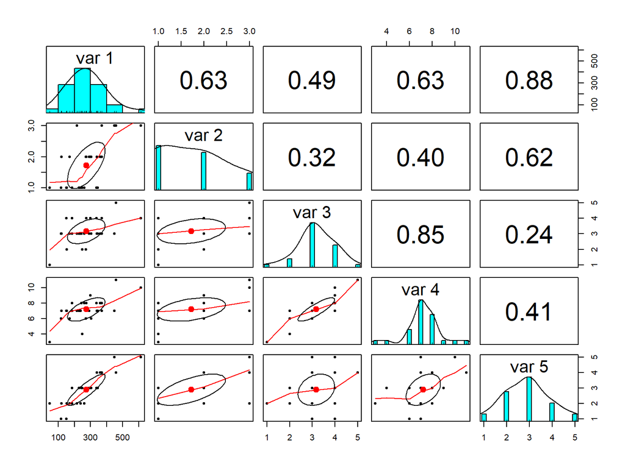

```r
subset <- cbind(homeprice$sale, homeprice$full, homeprice$bedrooms, homeprice$rooms, homeprice$neighborhood)
pairs.panels(subset)
```

- 변수1,5, 변수3,4 간에 강한 선형상관성이 있음으로 나왔다. - 변수1,5: 집값 homeprice가 이웃 평가 neighhood에 큰 영향을 받는다는 결과로 해석할 수 있다. 선형회귀 모델 구축 시 반드시 포함해야 한다. - 변수3,4: bedrooms와 rooms는 유사한 설명력을 갖고 있는 것으로 보인다. 둘을 독립변수로 사용하는 것은 중복(redundant)된 의미로, 다중공선성 문제가 된다. rooms만으로 모델을 구축하자.

## 2.1 집의 방의 갯수에 따른 집값 추이를 알아보자.

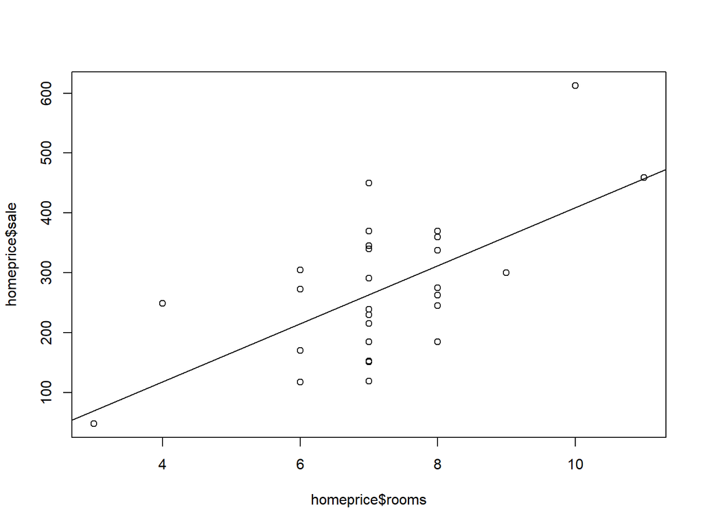

```r
m <- lm(sale ~ rooms, homeprice)
plot(homeprice$rooms, homeprice$sale)
abline(coef(m))
```

```r
summary(m)
```

```
##
## Call:
## lm(formula = sale ~ rooms, data = homeprice)
##
## Residuals:
##     Min      1Q  Median      3Q     Max
## -144.49  -60.46  -24.49   58.02  204.06
##
## Coefficients:
##             Estimate Std. Error t value Pr(>|t|)
## (Intercept)   -75.88      85.02  -0.893 0.379968
## rooms          48.48      11.55   4.197 0.000262 ***
## ---
## Signif. codes:  0 '***' 0.001 '**' 0.01 '*' 0.05 '.' 0.1 ' ' 1
##
## Residual standard error: 92.95 on 27 degrees of freedom
## Multiple R-squared:  0.3949, Adjusted R-squared:  0.3724
## F-statistic: 17.62 on 1 and 27 DF,  p-value: 0.0002621
```

## 2.2 이웃에 대한 평가에 따른

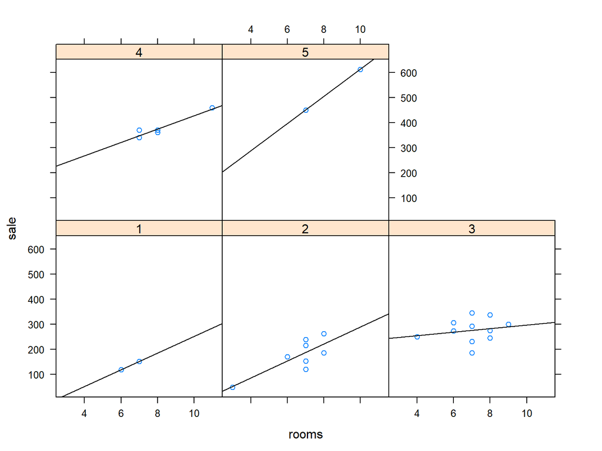

```r
# 평가를 factor  값으로 변환 (좋고 나쁨으로 보지 않겠다..)
homeprice$neighborhood <- as.factor(homeprice$neighborhood)

panel.lm <- function(x, y) {
  panel.xyplot(x, y)
  panel.abline(lm(y ~ x))
}

xyplot(sale ~ rooms | neighborhood, panel = panel.lm, data = homeprice)
```

- 설명: X축은 방의 수, Y축은 판매가격, 그리고 각 차트를 구분한 1-5점 사이는 이웃에 대한 평가 입니다. - 해석1: 이웃에 대한 점수가 낮기보다는 높을수록 판매가와 방의 수 모두 증가하는 패턴을 볼 수 있습니다. - 해석2: 이웃에 대한 평가 별 관측치가 단일하지 못합니다. 5단계 -> 3단계 정도로 나누어 분석해볼 필요가 있겠습니다.

```r
# 다시 numeric 값으로 변환
homeprice$neighborhood <- as.numeric(homeprice$neighborhood)

nbd <- as.numeric((cut(neighborhood, c(0,2,3,5), labels=c(1,2,3))))
table(nbd)
```

```
## nbd
##  1  2  3
## 10 12  7
```

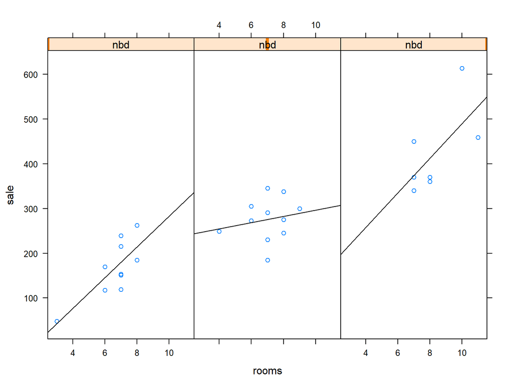

```r
xyplot(sale ~ rooms | nbd, panel = panel.lm, layout = c(3, 1))
```

- 설명1: 상위의 차트와 동일하게게 x축 방의 수, Y축 판매가격, 그리고 각 차트는 이웃에 대한 평가로 동일합니다. 하지만, 이웃 평가를 3단계로 등간화 했습니다. - 설명2: 상대적으로 관측수가 적은 이웃평가 점수 관측치가 있으므로, 3그룹으로 다시 묶어서 분류 - 설명3: 각 차트 별로 (왼쪽부터) 하, 중, 상의 이미 - 해석: 이웃 평가 점수가 높은 경우, 판매가도 높고 방의수도 많다고 해석할 수 있습니다. 하지만, 직접적인 인과관게를 의미하는 것은 아닙니다.

# 3 Bedroom & neighborhood 회귀분석

```r
model2 <- lm(sale ~ bedrooms + nbd)

summary(model2)
```

```
##
## Call:
## lm(formula = sale ~ bedrooms + nbd)
##
## Residuals:
##    Min     1Q Median     3Q    Max
## -94.27 -44.27 -14.80  25.73 182.56
##
## Coefficients:
##             Estimate Std. Error t value Pr(>|t|)
## (Intercept)   -58.90      48.54  -1.213   0.2359
## bedrooms       35.84      14.94   2.400   0.0239 *
## nbd           115.32      15.57   7.405  7.3e-08 ***
## ---
## Signif. codes:  0 '***' 0.001 '**' 0.01 '*' 0.05 '.' 0.1 ' ' 1
##
## Residual standard error: 60.33 on 26 degrees of freedom
## Multiple R-squared:  0.7545, Adjusted R-squared:  0.7356
## F-statistic: 39.95 on 2 and 26 DF,  p-value: 1.177e-08
```

```
- 잔차(residual) 해석: 윗쪽에서 방의 수(rooms) 만으로 예측했던 모델 대비, 잔차(residual)이 크게 줄어들었음을 알 수 있습니다.
- 변수 유의성(p-value) 해석: bedrooms, nbd의 p-value 모두 유의수준 0.05 보다 작습니다. 그러므로, 95%의 신뢰도를 기준으로 변수가 없을 때보다 있을 때 유의미하다고 해석합니다.
- 변수 영향도 해석: bedrooms, nbd 변수의 파라미터(Beta) 값은 각 35,84, 115.32 입니다. 방 1개 추가시 가격은 $35,000 증가하고, 이웃 평가 1단계가 증가시 $115,320 증가합니다. nbd가 bedrooms 보다 가격 상승에 큰 영향이 있다고 설명합니다.
* 앞에서 설명하지 않았는데, 유의수준(*)을 의미하는 마크의 갯수가 늘어날수록 통계적으로 귀무가설을 기각할 확률이 커집니다. 이 유의수준은 사람이 지정하는 Hyperparameter입니다.
```

# 4 변수에 Full bathroom을 추가하여 회귀분석

```r
model3 <- lm(sale ~ bedrooms + nbd + full)
summary(model3)
```

```
##
## Call:
## lm(formula = sale ~ bedrooms + nbd + full)
##
## Residuals:
##    Min     1Q Median     3Q    Max
## -72.85 -43.11 -15.36  22.89 165.38
##
## Coefficients:
##             Estimate Std. Error t value Pr(>|t|)
## (Intercept)   -67.89      47.58  -1.427   0.1660
## bedrooms       31.74      14.77   2.149   0.0415 *
## nbd           101.00      17.69   5.709 6.04e-06 ***
## full           28.51      18.19   1.567   0.1297
## ---
## Signif. codes:  0 '***' 0.001 '**' 0.01 '*' 0.05 '.' 0.1 ' ' 1
##
## Residual standard error: 58.71 on 25 degrees of freedom
## Multiple R-squared:  0.7764, Adjusted R-squared:  0.7496
## F-statistic: 28.94 on 3 and 25 DF,  p-value: 2.694e-08
```

```
- Full bathroom이 설치되었는지에 따라 $28,000 가치가 오른다는 평가가 나왔습니다. 하지만, 유의수준(alpha)을 어떻게 정하느냐에 따라, 유의하지 못한 변수가 될 수 있습니다.
```

# 5 full bathroom 변수 제거 전후에 대한 분산분석

```r
anova(model2, model3)
```

```
## Analysis of Variance Table
##
## Model 1: sale ~ bedrooms + nbd
## Model 2: sale ~ bedrooms + nbd + full
##   Res.Df   RSS Df Sum of Sq     F Pr(>F)
## 1     26 94646
## 2     25 86179  1    8466.2 2.456 0.1297
```

```
- p-value가 0.1297이 나왔다. 여기서 귀무가설은 "두 모델 간 차이가 없다.", 대립가설은 "두 모델 간 차이가 있다." 이다. p-value가 유의수준 0.05보다 크기 때문에 귀무가설을 기각할 수 없다. 즉, full bathroom을 포함하거나 안하거나 차이가 없다고 해석한다.
```

# 6 Dummary variable 추가

- 앞에서 이웃 평간 점수를 5등간 -> 3등간 했던 것은 질적자료의 의미가 큽니다.
- 회귀분석에서는 독립변수가 nuemric 이어야 하는데, factor인 경우 dummy variable로 변환하여 사용해야 합니다.

```r
# R에서는 변수명에 마침표(.)가 들어가도 됩니다.
nbd.f <- as.factor(nbd)
homeprice <- cbind(homeprice, nbd.f)
str(homeprice)
```

```
## 'data.frame':    29 obs. of  8 variables:
##  $ list        : num  80 151 310 295 339 ...
##  $ sale        : num  118 151 300 275 340 ...
##  $ full        : num  1 1 2 2 2 1 3 1 1 1 ...
##  $ half        : num  0 0 1 1 0 1 0 1 2 0 ...
##  $ bedrooms    : num  3 4 4 4 3 4 3 3 3 1 ...
##  $ rooms       : num  6 7 9 8 7 8 7 7 7 3 ...
##  $ neighborhood: num  1 1 3 3 4 3 2 2 3 2 ...
##  $ nbd.f       : Factor w/ 3 levels "1","2","3": 1 1 2 2 3 2 1 1 2 1 ...
```

```
- Factor 타입인 nbd를 numeric이 아닌 dummy 변수, nbd.lv1, nbd.lv2, nbd.lv3 생성
```

```r
#nbd.lv1 <- (nbd == "1")*1 lv1은 '0'이라는 의미가 이미 있으므로 생략
nbd.lv2 <- (nbd == "2")*1
nbd.lv3 <- (nbd == "3")*1
homeprice <- cbind(homeprice, nbd.lv2, nbd.lv3)
str(homeprice)
```

```
## 'data.frame':    29 obs. of  10 variables:
##  $ list        : num  80 151 310 295 339 ...
##  $ sale        : num  118 151 300 275 340 ...
##  $ full        : num  1 1 2 2 2 1 3 1 1 1 ...
##  $ half        : num  0 0 1 1 0 1 0 1 2 0 ...
##  $ bedrooms    : num  3 4 4 4 3 4 3 3 3 1 ...
##  $ rooms       : num  6 7 9 8 7 8 7 7 7 3 ...
##  $ neighborhood: num  1 1 3 3 4 3 2 2 3 2 ...
##  $ nbd.f       : Factor w/ 3 levels "1","2","3": 1 1 2 2 3 2 1 1 2 1 ...
##  $ nbd.lv2     : num  0 0 1 1 0 1 0 0 1 0 ...
##  $ nbd.lv3     : num  0 0 0 0 1 0 0 0 0 0 ...
```

하지만, 사실 R의 lm 모델 구축 시에는 자동적으로 factor 타입을 dummary variables로 변환해주고 분석  
- 아래 두가지 방식으로 모델링한 결과를 보자.

```r
model4 <- lm(sale ~ bedrooms + nbd.lv2 + nbd.lv3)
summary(model4)
```

```
##
## Call:
## lm(formula = sale ~ bedrooms + nbd.lv2 + nbd.lv3)
##
## Residuals:
##    Min     1Q Median     3Q    Max
## -84.94 -42.93 -14.66  35.06 174.70
##
## Coefficients:
##             Estimate Std. Error t value Pr(>|t|)
## (Intercept)    63.46      47.84   1.326 0.196667
## bedrooms       35.37      15.10   2.342 0.027442 *
## nbd.lv2       100.38      26.40   3.803 0.000821 ***
## nbd.lv3       233.38      31.69   7.364 1.03e-07 ***
## ---
## Signif. codes:  0 '***' 0.001 '**' 0.01 '*' 0.05 '.' 0.1 ' ' 1
##
## Residual standard error: 60.93 on 25 degrees of freedom
## Multiple R-squared:  0.7593, Adjusted R-squared:  0.7304
## F-statistic: 26.28 on 3 and 25 DF,  p-value: 6.73e-08
```

```
- p-value를 봤을 때, 모든 변수 의미한 결과가 나왔다.
```

```r
model5 <- lm(sale ~ bedrooms + nbd.f)
summary(model5)
```

```
##
## Call:
## lm(formula = sale ~ bedrooms + nbd.f)
##
## Residuals:
##    Min     1Q Median     3Q    Max
## -84.94 -42.93 -14.66  35.06 174.70
##
## Coefficients:
##             Estimate Std. Error t value Pr(>|t|)
## (Intercept)    63.46      47.84   1.326 0.196667
## bedrooms       35.37      15.10   2.342 0.027442 *
## nbd.f2        100.38      26.40   3.803 0.000821 ***
## nbd.f3        233.38      31.69   7.364 1.03e-07 ***
## ---
## Signif. codes:  0 '***' 0.001 '**' 0.01 '*' 0.05 '.' 0.1 ' ' 1
##
## Residual standard error: 60.93 on 25 degrees of freedom
## Multiple R-squared:  0.7593, Adjusted R-squared:  0.7304
## F-statistic: 26.28 on 3 and 25 DF,  p-value: 6.73e-08
```

```
- model4, model5 결과가 동일한 것을 알 수 있다.
```

데이터 분석 시, numeric 보다 factor 타입의 qualitative variable이 함께 포함되는 경우가 잦다. R에서 선형회귀 분석 시, 필히 factor 타입으로 변환 후에 모델을 구축해야 한다.